# Workflow

### 5.2.1 Préparation du fichier

```r
# Chargement fichier HPO
hpo_url <- "https://raw.githubusercontent.com/obophenotype/human-phenotype-ontology/master/hp.obo"

# Récupération de l'ontologie et des noms exacts de chaque phénotype
hpo <- get_ontology(hpo_url, extract_tags = 'everything')
name_ph <- hpo$name
formatted_colnames <- gsub("\\.", ":", colnames(phenotype_maladie_s_c))
# Remplacement des codes phénotypes par les noms exacts
colnames(phenotype_maladie_s_c) <- name_ph[formatted_colnames]

# transformation au format long
df_long <- melt(as.matrix(phenotype_maladie_s_c))
colnames(df_long) <- c('maladie','phenotype','presence')
liste_phenotype <- df_long %>%
  filter(presence == 1) %>%
  group_by(maladie) %>%
  summarise( liste_phenotype = paste('We are a group of individuals suffering from the same disease, but it manifests itself differently in each of us. Here is a list of the symptoms we may experience',
                                     paste(phenotype,
                                           collapse = ", "),
                                     sep = ' : '),
             .groups = 'drop')
liste_phenotype <- unique(liste_phenotype)[,2]

# Sauvegarde du fichier
write_csv(x = liste_phenotype,file = 'embedding_0hierarchie.csv')
```

### 5.2.2 Calcul des coordonnées

Le calcul des coordonnées a été réalisé sur Python avec le modèle **SBERT**. Le résultat de l’embedding a été sauvegardé dans le fichier `embeddings_Pheno_SBERT_sans_hierarchie.csv`

```r
coord_fact_embedding <- read.csv("embeddings_Pheno_SBERT_sans_hierarchie.csv")
```

## 5.3 ACM

L’objectif de cette ACM (Analyse des Correspondances Multiples) est de projeter les maladies complexes dans un espace défini par les maladies simples. Pour ce faire, les maladies complexes sont traitées comme des individus supplémentaires, tandis que l’espace de représentation est construit exclusivement à partir des maladies simples.

```r
# Calcul de l'ACM
dta_acm <- data.frame(lapply(phenotype_maladie_s_c, as.factor))
res.acm<- MCA(dta_acm, ind.sup = c(6103:7064), graph = TRUE, ncp=384)
save(res.acm, file = "res.acm.RData")

# Obtention des coordonnées
col_acm <- res.acm$ind$coord
row_acm <- res.acm$ind.sup$coord
coord_fact_acm <- rbind(col_acm, row_acm)
coord_fact_acm <- as.data.frame(coord_fact_acm)
save(coord_fact_acm, file = "coord_fact_acm.RData")
```

```r
load("res.acm.RData")
load("coord_fact_acm.RData")
```

# 6 **Comparaison de l’ensemble des méthodes**

Afin de comparer l’ensemble de nos méthodes, nous réalisons une Analyse Factorielle Multiple (AFM) sur les coordonnées obtenues par chaque méthodes sur l’ensemble de nos dimensions. Ainsi nous considérons nos dimensions comme des variables et nos méthodes comme des groupes.

## 6.1 Mise en forme des données pour l’AFM

```r
maladies_acm <- res.acm$ind.sup$coord
maladies_sorensen <- as.data.frame(coord_fact_mds_sorensen$conf.row)
maladies_ochiai <- as.data.frame(coord_fact_mds_ochiai$conf.row)
maladies_jaccard <- as.data.frame(coord_fact_mds_jaccard$conf.row)
maladies_ot_jaccard <- as.data.frame(coord_fact_mds_ot_jaccard$conf.row)
head(coord_fact_embedding)
maladies_embedding <- as.data.frame(coord_fact_embedding[6103:7064, ])
maladies_sokal_sneath <- as.data.frame(coord_fact_mds_sokal_sneath$conf.row)
maladies_sokal_michener <- as.data.frame(coord_fact_mds_sokal_michener$conf.row)
maladies_rogers_tanimoto <- as.data.frame(coord_fact_mds_rogers_tanimoto$conf.row)
maladies_hamann <- as.data.frame(coord_fact_mds_hamann$conf.row)
maladies_cosine <- as.data.frame(coord_fact_mds_cosine$conf.row)

data_pour_afm.toutes.distances <- cbind(maladies_acm,
                                        maladies_sorensen,
                                        maladies_ochiai,
                                        maladies_jaccard,
                                        maladies_ot_jaccard,
                                        maladies_embedding,  # Données existantes
                                        maladies_sokal_sneath,
                                        maladies_sokal_michener,
                                        maladies_rogers_tanimoto,
                                        maladies_hamann,
                                        maladies_cosine)
save(data_pour_afm.toutes.distances, file = "data_pour_afm.toutes.distances.RData")
```

## 6.2 AFM

```r
load("data_pour_afm.toutes.distances.RData")
res.mfa.toutes.distances <- MFA(data_pour_afm.toutes.distances,
                                group = c(384, 384, 384, 384, 384, 384,  # Groupes existants
                                          384, 384, 384, 384, 384),  # Nouveaux groupes
                                type = c("c", "c", "c", "c", "c", "c", "c", "c", "c", "c", "c"),
                                ncp = 2,
                                name.group = c("ACM", "Sorensen", "Ochiai", "Jaccard", "Jaccard_OT", "Embedding", "sokal_sneath", "sokal_michener",  "rogers_tanimoto", "Hamann", "Cosine"),graph = FALSE)
save(res.mfa.toutes.distances, file = "res.mfa.toutes.distances.RData")
```

## 6.3 Représentation graphique

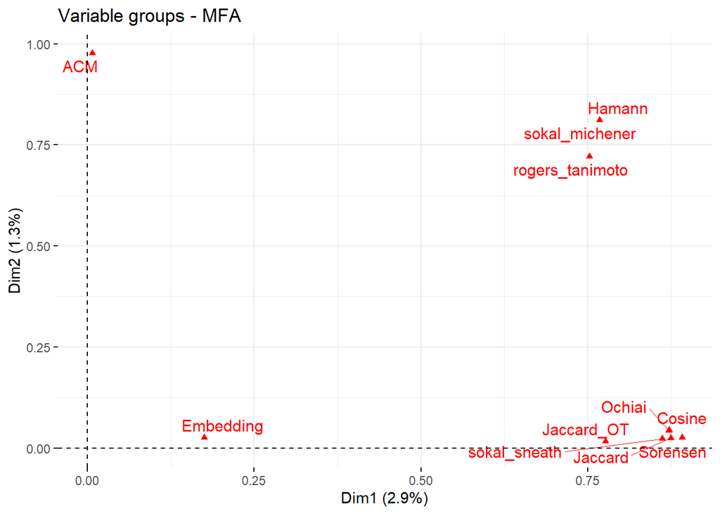

```r
load("res.mfa.toutes.distances.RData")
# Définir les couleurs dans l'ordre des groupes
custom_colors <- c(
  "forestgreen",  # ACM
  "red",          # Cosine
  "cyan",         # Embedding
  "black"   ,     # Hamann
  "orange",       # Jaccard
  "grey",         # Jaccard_OT
  "magenta",      # Ochiai
  "green",        # rogers_tanimoto
  "pink",         # sokal_michener
  "skyblue",      # sokal_sneath
  "blue"          # Sorensen

)

name.group = c("ACM", "Sorensen", "Ochiai", "Jaccard", "Jaccard_OT", "Embedding", "sokal_sneath", "sokal_michener",  "rogers_tanimoto", "Hamann", "Cosine")


fviz_mfa_var(res.mfa.toutes.distances,
                     choice = 'group',
                     geom = c("point", "text"),
                     repel = TRUE)
```

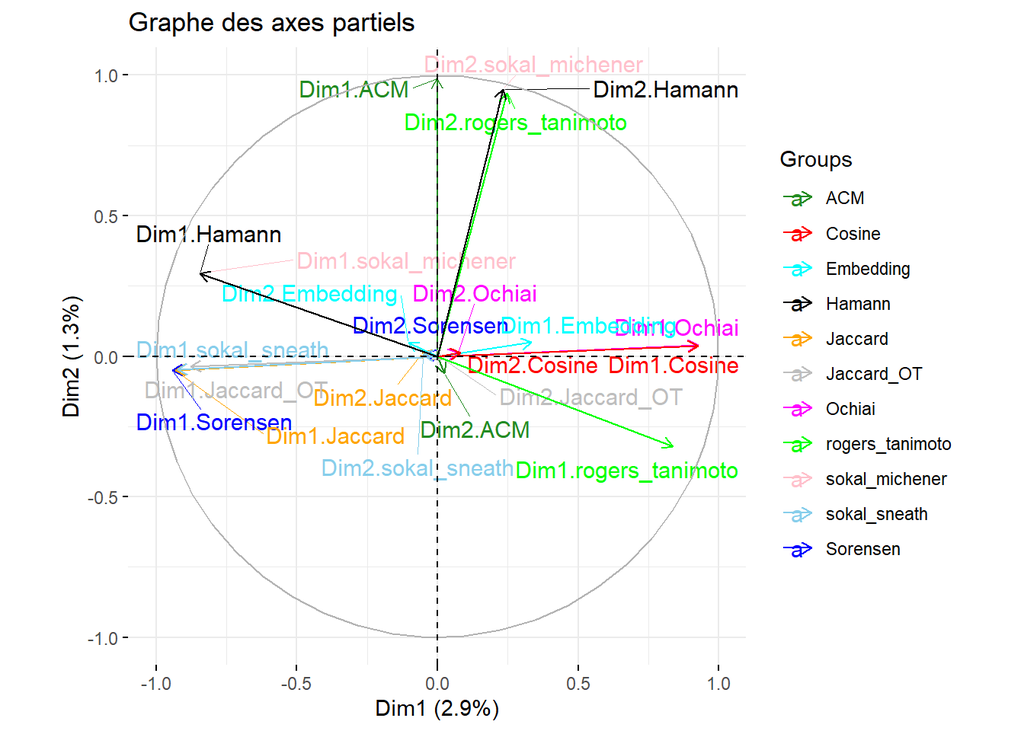

```r
fviz_mfa_axes(res.mfa.toutes.distances,
         geom = c('arrow','text'),
         title = "Graphe des axes partiels",
         palette = custom_colors,
         repel = TRUE)
```

# 7 **Assignation de gènes**

## 7.1 Permutations

Une fois les coordonnées obtenues, il est nécessaire de définir un seuil permettant d’apparier les maladies complexes aux gènes. Autrement dit, il s’agit de déterminer une valeur critique au-delà de laquelle une association entre une maladie complexe et une maladie simple sera considérée comme significative.

Dans cette section, nous expliquons comment la p-value critique a été estimée pour chaque maladie. L’objectif est d’évaluer les associations significatives en permutant aléatoirement les valeurs binaires (0 et 1) associées à la maladie complexe, tout en maintenant la proportion initiale de 0 et 1 et en conservant inchangées les données des autres maladies simples. Ces permutations brisent les relations existantes, et après chaque permutation, les distances entre la maladie complexe et les maladies simples sont recalculées. En répétant ce processus plusieurs fois, on construit une distribution empirique des distances sous l’hypothèse nulle (absence d’association réelle). La valeur minimale des distances obtenues pour chaque permutation est utilisée comme seuil critique. Enfin, la distance réelle entre la maladie complexe non permutée et les maladies simples est comparée à cette distribution : si elle est inférieure au seuil critique, l’association est jugée significative, confirmant qu’elle n’est pas due au hasard. Ce processus permet d’identifier des relations pertinentes tout en contrôlant le risque d’erreur statistique.

### 7.1.1 Définnition des fonctions

```r
# Fonctions vectorisées pour chaque type de distance afin d'effectuer plus rapidement les calculs
calc_distances <- function(matrix1, vector1, method = "sorensen") {
  # Calcul du nombre d'éléments communs (intersections)
  a <- matrix1 %*% vector1
  # Nombre total d'éléments dans chaque ligne de la matrice
  nb_elements_ensemble1 <- rowSums(matrix1)
  b = nb_elements_ensemble1 - a
  # Nombre total d'éléments dans le vecteur
  nb_elements_ensemble2 <- sum(vector1)
  c = nb_elements_ensemble2 - a
  # Calcul du nombre d'éléments présents dans aucun des deux ensembles (d)
  d <- ncol(matrix1) - (a + b + c)
  switch(method,
         "jaccard" = {
           sqrt(1-((a) / (a + b + c)))
         },
         "sokal_michener" = {
           sqrt(1-((a + d )/ (a + b + c+ d)))
         },
         "sokal_sneath" = {
           sqrt(1-((a * d) / (sqrt((a + b) + (a + c)+ (d + b) + (d + c)))))
         },
         "rogers_tanimoto" = {
           sqrt(1-((a + d )/ (a + 2*(b + c)+ d)))
         },
         "sorensen" = {
           sqrt(1-((2*a)/ (2*a + b + c)))
         },
         "hamann" = {
           sqrt(1-((a-(b + c) + d)/(a + b + c+ d)))
         },
         "ochiai" = {
           sqrt(1-((a)/(sqrt(a + b)+(a + c))))
         },
         "cosinus" = {
           1-((a)/(sqrt(a + b)+(a + c)))
         }
  )
}

# Fonction de permutation pour une ligne
permut_all <- function(dta, n_perm, line_idx, distance_method = "sorensen") {
  dta <- as.matrix(dta)
  row <- dta[line_idx, ]
  original_rowname <- rownames(dta)[line_idx]
  pmin <- numeric(n_perm)
  other_rows <- matrix(as.numeric(dta[-line_idx, ]),
                       nrow = nrow(dta) - 1,
                       byrow = FALSE)
  for(i in 1:n_perm) {
    permuted_row <- sample(row, length(row), replace = FALSE)
    distances <- calc_distances(other_rows, permuted_row, method = distance_method)
    pmin[i] <- min(distances)
  }

  return(c(rowname = original_rowname, threshold = min(pmin)))
}

# Fonction pour traiter plusieurs lignes
process_multiple_rows <- function(dta, n_perm, start_idx, end_idx, distance_method = "sorensen") {
  n_rows <- end_idx - start_idx + 1
  results <- matrix(nrow = n_rows, ncol = 2)
  for(i in 1:n_rows) {
    curr_idx <- start_idx + i - 1
    results[i, ] <- permut_all(dta, n_perm, curr_idx, distance_method)
  }
  results_df <- as.data.frame(results)
  colnames(results_df) <- c("rowname", "threshold")
  return(results_df)
}

# Fonction pour exécuter toutes les méthodes de distance
run_all_distances <- function(phenotype_matrix, n_perm = 10, start_idx = 6103, end_idx = 7064) {
  distance_methods <- c("sorensen", "ochiai", "jaccard", "sokal_sneath",
                        "sokal_michener", "rogers_tanimoto", "hamann", "cosinus")
  results <- list()
  for(method in distance_methods) {
    cat("Processing", method, "distance...\n")
    results[[method]] <- process_multiple_rows(
      phenotype_matrix,
      n_perm = n_perm,
      start_idx = start_idx,
      end_idx = end_idx,
      distance_method = method
    )
    results[[method]]$threshold <- as.numeric(results[[method]]$threshold)
  }
  return(results)
}
```

### 7.1.2 Application des permutations

```r
# Exécuter toutes les distances
results_all <- run_all_distances(phenotype_maladie_s_c)
save(results_all, file="results_all_distances.RData")
```

```r
load ("results_all_distances.RData")
```

### 7.1.3 Création des matrices d’assignation

```r
# Matrice d'assignation  ----
create_all_association_matrices <- function(results_all) {
  # Liste des matrices de distance à charger
  distance_files <- list(
    sorensen = "dist_or_sorensen_mx.RData",
    ochiai = "dist_or_ochiai_mx.RData",
    jaccard = "dist_or_jaccard_mx.RData",
    sokal_sneath = "dist_or_sokal_sneath_mx.RData",
    sokal_michener = "dist_or_sokal_michener_mx.RData",
    rogers_tanimoto = "dist_or_rogers_tanimoto_mx.RData",
    hamann = "dist_or_hamann_mx.RData",
    cosine = "dist_cosine_mx.RData"
  )
  # Stocker les résultats
  association_matrices <- list()
  # Pour chaque distance
  for(dist_name in names(distance_files)) {
    # Charger la matrice de distance
    load(distance_files[[dist_name]])
    # Obtenir le nom de l'objet chargé
    dist_matrix_name <- gsub("\\.RData$", "", distance_files[[dist_name]])
    dist_matrix <- get(dist_matrix_name)
    # Créer la matrice d'association
    cat("Processing", dist_name, "distance...\n")
    # Conversion en dataframe
    dist_df <- as.data.frame(dist_matrix)
    # Créer une matrice vide
    association_matrix <- matrix(0, nrow = nrow(dist_df), ncol = ncol(dist_df))
    # Pour chaque ligne
    for(i in 1:nrow(dist_df)) {
      # Récupérer le seuil correspondant
      current_threshold <- results_all[[dist_name]]$threshold[i]
      # Comparer les valeurs au seuil
      association_matrix[i,] <- ifelse(dist_df[i,] <= current_threshold, 1, 0)
    }
    # Convertir en dataframe
    association_matrix <- as.data.frame(association_matrix)
    rownames(association_matrix) <- rownames(dist_df)
    colnames(association_matrix) <- colnames(dist_df)
    # Stocker la matrice
    association_matrices[[dist_name]] <- association_matrix
    # Sauvegarder la matrice
    save_name <- paste0("association_matrix_", dist_name, ".RData")
    save(association_matrix, file = save_name)
  }
  return(association_matrices)
}
```

```r
# Créer toutes les matrices d'association
association_matrices <- create_all_association_matrices(results_all)
save(association_matrices, file="association_matrices.RData")
```

```r
load("association_matrices.RData")
```

## 7.2 Classification

Une autre méthode afin d’obtenir une matrice d’assignation est de passer par une classification. Contrairement aux permutations, la classification peut être utilisée pour l’ensemble des méthodes et non seulement pour les matrices de distances.

La réalisation d’une classification pose certaines contraintes. Habituellement, un individu sera présent dans une seule classe. Or dans notre contexte, nous considérons qu’un gène est en mesure d’expliquer plusieurs maladies complexes.

### 7.2.1 Préparation des données

```r
row_sorensen = coord_fact_mds_sorensen$conf.row
row_sorensen <- as.data.frame(row_sorensen)
col_sorensen = coord_fact_mds_sorensen$conf.col
col_sorensen <- as.data.frame(col_sorensen)
data_classif_sorensen <- rbind(row_sorensen, col_sorensen)

row_ochiai = coord_fact_mds_ochiai$conf.row
row_ochiai <- as.data.frame(row_ochiai)
col_ochiai = coord_fact_mds_ochiai$conf.col
col_ochiai  <- as.data.frame(col_ochiai )
data_classif_ochiai <- rbind(row_ochiai, col_ochiai)

row_jaccard = coord_fact_mds_jaccard$conf.row
row_jaccard <- as.data.frame(row_jaccard)
col_jaccard = coord_fact_mds_jaccard$conf.col
col_jaccard <- as.data.frame(col_jaccard)
data_classif_jaccard <- rbind(row_jaccard, col_jaccard)

row_ot_jaccard = coord_fact_mds_ot_jaccard$conf.row
row_ot_jaccard <- as.data.frame(row_ot_jaccard)
col_ot_jaccard = coord_fact_mds_ot_jaccard$conf.col
col_ot_jaccard <- as.data.frame(col_ot_jaccard)
data_classif_ot_jaccard <- rbind(row_ot_jaccard, col_ot_jaccard)

data_classif_sokal_sneath <- rbind(coord_fact_mds_sokal_sneath$conf.row, coord_fact_mds_sokal_sneath$conf.col)
data_classif_sokal_michener <- rbind(coord_fact_mds_sokal_michener$conf.row, coord_fact_mds_sokal_michener$conf.col)
data_classif_rogers_tanimoto <- rbind(coord_fact_mds_rogers_tanimoto$conf.row, coord_fact_mds_rogers_tanimoto$conf.col)
data_classif_hamann <- rbind(coord_fact_mds_hamann$conf.row, coord_fact_mds_hamann$conf.col)
data_classif_cosine <- rbind(coord_fact_mds_cosine$conf.row, coord_fact_mds_cosine$conf.col)
data_classif_cosine <- as.data.frame(data_classif_cosine)
data_classif_hamann <- as.data.frame(data_classif_hamann)
data_classif_sokal_michener <- as.data.frame(data_classif_sokal_michener)
data_classif_rogers_tanimoto <- as.data.frame(data_classif_rogers_tanimoto)

data_classif_embedding <- as.data.frame(coord_fact_embedding)
section1 <- data_classif_embedding[1:6102, ]
section2 <- data_classif_embedding[6103:7064, ]
data_classif_embedding <- rbind(section2, section1)
rownames(data_classif_embedding) <- 1:nrow(data_classif_embedding)

data_classif_acm <- as.data.frame(coord_fact_acm)
section1 <- data_classif_acm[1:6102, ]
section2 <- data_classif_acm[6103:7064, ]
data_classif_acm <- rbind(section2, section1)
rownames(data_classif_acm) <- 1:nrow(data_classif_acm)
save(data_classif_acm, file = "data_classif_acm.RData")

names(data_classif_sorensen) <- paste0("D", 1:ncol(data_classif_sorensen))
names(data_classif_ochiai) <- paste0("D", 1:ncol(data_classif_ochiai))
names(data_classif_jaccard) <- paste0("D", 1:ncol(data_classif_jaccard))
names(data_classif_ot_jaccard) <- paste0("D", 1:ncol(data_classif_ot_jaccard))
names(data_classif_embedding) <- paste0("D", 1:ncol(data_classif_embedding))
names(data_classif_acm) <- paste0("D", 1:ncol(data_classif_acm))
names(data_classif_sokal_sneath) <- paste0("D", 1:ncol(data_classif_sokal_sneath))
names(data_classif_sokal_michener) <- paste0("D", 1:ncol(data_classif_sokal_michener))
names(data_classif_rogers_tanimoto) <- paste0("D", 1:ncol(data_classif_rogers_tanimoto))
names(data_classif_hamann) <- paste0("D", 1:ncol(data_classif_hamann))
names(data_classif_cosine) <- paste0("D", 1:ncol(data_classif_cosine))


save(data_classif_sorensen, file="data_classif_sorensen.RData")
save(data_classif_ochiai, file="data_classif_ochiai.RData")
save(data_classif_jaccard, file="data_classif_jaccard.RData")
save(data_classif_ot_jaccard, file="data_classif_ot_jaccard.RData")
save(data_classif_embedding, file="data_classif_embedding.RData")
save(data_classif_acm, file="data_classif_acm.RData")
save(data_classif_sokal_sneath, file="data_classif_sokal_sneath.RData")
save(data_classif_sokal_michener, file="data_classif_sokal_michener.RData")
save(data_classif_rogers_tanimoto, file="data_classif_rogers_tanimoto.RData")
save(data_classif_hamann, file="data_classif_hamann.RData")
save(data_classif_cosine, file="data_classif_cosine.RData")
```

```r
load("data_classif_sorensen.RData")
load("data_classif_ochiai.RData")
load("data_classif_jaccard.RData")
load("data_classif_ot_jaccard.RData")
load("data_classif_embedding.RData")
load("data_classif_acm.RData")
load("data_classif_sokal_sneath.RData")
load("data_classif_sokal_michener.RData")
load("data_classif_rogers_tanimoto.RData")
load("data_classif_hamann.RData")
load("data_classif_cosine.RData")
```

### 7.2.2 Application de la classification

Nous avons décidé de réaliser une classification à 384 classes, correspondant aux 384 dimensions conservées pour toute les méthodes. Ce choix a été fait car réaliser une classification sur un nombre de classes plus élevés que le nombre de composantes peut s’avérer difficile.

```r
# Pour sorensen
hc_sorensen <- HCPC(data_classif_sorensen,
                    nb.clust = 384)
save(hc_sorensen, file="hc_sorensen.RData")

# Pour ochiai
hc_ochiai <- HCPC(data_classif_ochiai,
                  nb.clust = 384)
save(hc_ochiai, file="hc_ochiai.RData")

# Pour jaccard
hc_jaccard <- HCPC(data_classif_jaccard,
                   nb.clust = 384)
save(hc_jaccard, file="hc_jaccard.RData")

# Pour ot_jaccard
hc_ot_jaccard <- HCPC(data_classif_ot_jaccard,
                      nb.clust = 384)
save(hc_ot_jaccard, file="hc_ot_jaccard.RData")

# Pour embedding
hc_embedding <- HCPC(data_classif_embedding,
                     nb.clust = 384)
save(hc_embedding, file="hc_embedding.RData")

# Pour acm
hc_acm <- HCPC(data_classif_acm,
               nb.clust = 384)
save(hc_acm, file="hc_acm.RData")

# Pour sokal_sneath
hc_sokal_sneath <- HCPC(data_classif_sokal_sneath,
                        nb.clust = 384)
save(hc_sokal_sneath, file="hc_sokal_sneath.RData")

# Pour sokal_michener
hc_sokal_michener <- HCPC(data_classif_sokal_michener,
                          nb.clust = 384)
save(hc_sokal_michener, file="hc_sokal_michener.RData")

# Pour rogers_tanimoto
hc_rogers_tanimoto <- HCPC(data_classif_rogers_tanimoto,
                           nb.clust = 384)
save(hc_rogers_tanimoto, file="hc_rogers_tanimoto.RData")

# Pour hamann
hc_hamann <- HCPC(data_classif_hamann,
                  nb.clust = 384)
save(hc_hamann, file="hc_hamann.RData")

# Pour cosine
hc_cosine <- HCPC(data_classif_cosine,
                  nb.clust = 384)
save(hc_cosine, file="hc_cosine.RData")

# Création des nouvelles matrices d'assignation à partir du clustering ----
```

```r
load("hc_sorensen.RData")
load("hc_ochiai.RData")
load("hc_jaccard.RData")
load("hc_ot_jaccard.RData")
load("hc_embedding.RData")
load("hc_acm.RData")
load("hc_sokal_michener.RData")
load("hc_rogers_tanimoto.RData")
load("hc_hamann.RData")
load("hc_cosine.RData")
```

### 7.2.3 Transformation

```r
cluster_sorensen <- hc_sorensen$data.clust
cluster_ochiai <- hc_ochiai$data.clust
cluster_jaccard <- hc_jaccard$data.clust
cluster_ot_jaccard <- hc_ot_jaccard$data.clust
cluster_embedding <- hc_embedding$data.clust
cluster_acm <- hc_acm$data.clust
cluster_sokal_michener <- hc_sokal_michener$data.clust
cluster_rogers_tanimoto <- hc_rogers_tanimoto$data.clust
cluster_hamann <- hc_hamann$data.clust
cluster_cosine <- hc_cosine$data.clust

# Convert clustering results to assignment matrix
create_assignment_matrix <- function(cluster_data) {
  # Extract cluster assignments and row names
  cluster_assignments <- cluster_data[,385]
  all_names <- rownames(cluster_data)
  # Extract names of simple diseases (from index 965 to end)
  ms_names <- all_names[963:length(all_names)]
  mc_names <- all_names[1:962]
  # Create empty matrix
  n_mc <- 962
  n_ms <- 6102
  assignment_matrix <- matrix(0, nrow=n_mc, ncol=n_ms)
  # Fill matrix - 1 if MC and MS are in same cluster
  for(i in 1:n_mc) {
    for(j in 1:n_ms) {
      if(cluster_assignments[i] == cluster_assignments[j+962]) {
        assignment_matrix[i,j] <- 1
      }
    }
  }
  # Add row and column names
  rownames(assignment_matrix) <- mc_names
  colnames(assignment_matrix) <- ms_names
  return(assignment_matrix)
}
```

```r
assignment_matrix_sorensen_classif <- create_assignment_matrix(cluster_sorensen)
assignment_matrix_sorensen_classif <- as.data.frame(assignment_matrix_sorensen_classif)
save(assignment_matrix_sorensen_classif, file="assignment_matrix_sorensen_classif.RData")

assignment_matrix_ochiai_classif <- create_assignment_matrix(cluster_ochiai)
assignment_matrix_ochiai_classif <- as.data.frame(assignment_matrix_ochiai_classif)
save(assignment_matrix_ochiai_classif, file="assignment_matrix_ochiai_classif.RData")

assignment_matrix_jaccard_classif <- create_assignment_matrix(cluster_jaccard)
assignment_matrix_jaccard_classif <- as.data.frame(assignment_matrix_jaccard_classif)
save(assignment_matrix_jaccard_classif, file="assignment_matrix_jaccard_classif.RData")

assignment_matrix_ot_jaccard_classif <- create_assignment_matrix(cluster_ot_jaccard)
assignment_matrix_ot_jaccard_classif <- as.data.frame(assignment_matrix_ot_jaccard_classif)
save(assignment_matrix_ot_jaccard_classif, file="assignment_matrix_ot_jaccard_classif.RData")

assignment_matrix_embedding_classif <- create_assignment_matrix(cluster_embedding)
assignment_matrix_embedding_classif <- as.data.frame(assignment_matrix_embedding_classif)
save(assignment_matrix_embedding_classif, file="assignment_matrix_embedding_classif.RData")

assignment_matrix_acm_classif <- create_assignment_matrix(cluster_acm)
assignment_matrix_acm_classif <- as.data.frame(assignment_matrix_acm_classif)
save(assignment_matrix_acm_classif, file="assignment_matrix_acm_classif.RData")

assignment_matrix_sokal_michener_classif <- create_assignment_matrix(cluster_sokal_michener)
assignment_matrix_sokal_michener_classif <- as.data.frame(assignment_matrix_sokal_michener_classif)
save(assignment_matrix_sokal_michener_classif, file="assignment_matrix_sokal_michener_classif.RData")

assignment_matrix_rogers_tanimoto_classif <- create_assignment_matrix(cluster_rogers_tanimoto)
assignment_matrix_rogers_tanimoto_classif <- as.data.frame(assignment_matrix_rogers_tanimoto_classif)
save(assignment_matrix_rogers_tanimoto_classif, file="assignment_matrix_rogers_tanimoto_classif.RData")

assignment_matrix_hamann_classif <- create_assignment_matrix(cluster_hamann)
assignment_matrix_hamann_classif <- as.data.frame(assignment_matrix_hamann_classif)
save(assignment_matrix_hamann_classif, file="assignment_matrix_hamann_classif.RData")

assignment_matrix_cosine_classif <- create_assignment_matrix(cluster_cosine)
assignment_matrix_cosine_classif <- as.data.frame(assignment_matrix_cosine_classif)
save(assignment_matrix_cosine_classif, file="assignment_matrix_cosine_classif.RData")
```

```r
load("assignment_matrix_sorensen_classif.RData")
load("assignment_matrix_ochiai_classif.RData")
load("assignment_matrix_jaccard_classif.RData")
load("assignment_matrix_ot_jaccard_classif.RData")
load("assignment_matrix_embedding_classif.RData")
load("assignment_matrix_acm_classif.RData")
load("assignment_matrix_sokal_michener_classif.RData")
load("assignment_matrix_rogers_tanimoto_classif.RData")
load("assignment_matrix_hamann_classif.RData")
load("assignment_matrix_cosine_classif.RData")

rownames(assignment_matrix_sorensen_classif) <- rownames(phenotype_maladie_s_c[6103:7064,])
colnames(assignment_matrix_sorensen_classif) <- rownames(phenotype_maladie_s_c[1:6102,])

rownames(assignment_matrix_ochiai_classif) <- rownames(phenotype_maladie_s_c[6103:7064,])
colnames(assignment_matrix_ochiai_classif) <- rownames(phenotype_maladie_s_c[1:6102,])

rownames(assignment_matrix_jaccard_classif) <- rownames(phenotype_maladie_s_c[6103:7064,])
colnames(assignment_matrix_jaccard_classif) <- rownames(phenotype_maladie_s_c[1:6102,])

rownames(assignment_matrix_ot_jaccard_classif) <- rownames(phenotype_maladie_s_c[6103:7064,])
colnames(assignment_matrix_ot_jaccard_classif) <- rownames(phenotype_maladie_s_c[1:6102,])

rownames(assignment_matrix_embedding_classif) <- rownames(phenotype_maladie_s_c[6103:7064,])
colnames(assignment_matrix_embedding_classif) <- rownames(phenotype_maladie_s_c[1:6102,])

rownames(assignment_matrix_acm_classif) <- rownames(phenotype_maladie_s_c[6103:7064,])
colnames(assignment_matrix_acm_classif) <- rownames(phenotype_maladie_s_c[1:6102,])

rownames(assignment_matrix_sokal_michener_classif) <- rownames(phenotype_maladie_s_c[6103:7064,])
colnames(assignment_matrix_sokal_michener_classif) <- rownames(phenotype_maladie_s_c[1:6102,])

rownames(assignment_matrix_rogers_tanimoto_classif) <- rownames(phenotype_maladie_s_c[6103:7064,])
colnames(assignment_matrix_rogers_tanimoto_classif) <- rownames(phenotype_maladie_s_c[1:6102,])

rownames(assignment_matrix_hamann_classif) <- rownames(phenotype_maladie_s_c[6103:7064,])
colnames(assignment_matrix_hamann_classif) <- rownames(phenotype_maladie_s_c[1:6102,])

rownames(assignment_matrix_cosine_classif) <- rownames(phenotype_maladie_s_c[6103:7064,])
colnames(assignment_matrix_cosine_classif) <- rownames(phenotype_maladie_s_c[1:6102,])
```

# 8 **LLM**

Une fois les matrices d’assignation obtenues, nous pouvons récupérer une liste de gènes pour chaque maladie complexe. Afin d’interpréter ces listes, nous faisons appel à un large modèle de langage (LLM).

L’objectif est de donner, à chaque association gène-maladie, un score de pertinence prenant en compte la littérature sur le sujet, les processus biologiques impactés et la comparaison avec des gènes et des processus similaires.

Pour des raisons d’automatisation, nous nous sommes concentrés sur les llm gratuits. Nous avons utilisé `llama3` issu de Ollama pour obtenir un score d’association avec le prompt suivant.

*Question: Based on the function of the `[GENE]` gene, could this gene be involved in the development of `[MALADIE]`? Quantify on a scale from 0 to 10 the potential causal relationship between `[GENE]` variations and `[MALADIE]`, considering both direct evidence and mechanistic plausibility.*

*0-2: No or very weak scientific evidence and low mechanistic plausibility* *3-5: Limited direct evidence but significant mechanistic plausibility based on known pathways* *6-8: Strong mechanistic evidence and/or some direct clinical evidence* *9-10: Well-established causal relationship with validated mechanisms*

*Consider:* *1. Direct evidence* *2. Molecular pathway analysis* *3. Physiological relevance* *4. Comparative analysis: similar genes/pathways*

*RESPOND EXACTLY LIKE THIS TEMPLATE:* *SCORE: [enter single number 0-10]* *REASON: [enter one short sentence]*

Nous réalisons, pour chaque association gène-maladie, plusieurs itérations de ce prompt. Un score moyen et un intervalle de confiance sont ensuite calculés.

Le temps de calcul pour l’ensemble des associations étant très long, nous avons créé une application Shiny afin de limiter les calculs nécessaires et permettre à l’utilisateur de regarder uniquement les associations d’intérêt pour lui. Cette application récupère uniquement les différentes matrices d’associations dans le fichier `association_matrices_2.RData` et permet de créer une matrice consensus.

## 8.1 Préparation des données

```r
load('association_matrix_sorensen.RData')
sorensen_permut <- association_matrix
load('association_matrix_sokal_sneath.RData')
sokal_sneath_permut <- association_matrix_sokal_sneath
load('association_matrix_sokal_michener.RData')
sokal_michener_permut <- association_matrix
load('association_matrix_rogers_tanimoto.RData')
rogers_tanimoto_permut <- association_matrix
load('association_matrix_ochiai.RData')
ochiai_permut <- association_matrix
load('association_matrix_jaccard.RData')
jaccard_permut <- association_matrix
load('association_matrix_hamann.RData')
hamann_permut <- association_matrix
load('association_matrix_cosine.RData')
cosine_permut <- association_matrix_cosine

load("assignment_matrix_sorensen_classif.RData")
sorensen_classif <- assignment_matrix_sorensen_classif
load("assignment_matrix_ochiai_classif.RData")
ochiai_classif <- assignment_matrix_ochiai_classif
load("assignment_matrix_jaccard_classif.RData")
jaccard_classif <- assignment_matrix_jaccard_classif
load("assignment_matrix_ot_jaccard_classif.RData")
ot_jaccard_classif <- assignment_matrix_ot_jaccard_classif
load("assignment_matrix_embedding_classif.RData")
embedding_classif <- assignment_matrix_embedding_classif
load("assignment_matrix_acm_classif.RData")
acm_classif <- assignment_matrix_acm_classif
load("assignment_matrix_sokal_michener_classif.RData")
sokal_michener_classif <- assignment_matrix_sokal_michener_classif
load('assignment_matrix_sokal_sneath_classif.RData')
sokal_sneath_classif <- assignment_matrix_sokal_sneath_classif
load("assignment_matrix_rogers_tanimoto_classif.RData")
rogers_tanimoto_classif <- assignment_matrix_rogers_tanimoto_classif
load("assignment_matrix_hamann_classif.RData")
hamann_classif <- assignment_matrix_hamann_classif
load("assignment_matrix_cosine_classif.RData")
cosine_classif <- assignment_matrix_cosine_classif


association_matrices <- list(jaccard_permut=jaccard_permut,
                             jaccard_classif=jaccard_classif,
                             ot_jaccard_classif=ot_jaccard_classif,
                             sorensen_permut=sorensen_permut,
                             sorensen_classif=sorensen_classif,
                             sokal_sneath_permut=sokal_sneath_permut,
                             sokal_sneath_classif=sokal_sneath_classif,
                             ochiai_permut=ochiai_permut,
                             ochiai_classif=ochiai_classif,
                             cosine_permut=cosine_permut,
                             cosine_classif=cosine_classif,
                             rogers_tanimoto_permut=rogers_tanimoto_permut,
                             rogers_tanimoto_classif=rogers_tanimoto_classif,
                             hamann_permut=hamann_permut,
                             hamann_classif=hamann_classif,
                             sokal_michener_permut=sokal_michener_permut,
                             sokal_michener_classif=sokal_michener_classif,
                             acm_classif=acm_classif,
                             embedding_classif=embedding_classif
                             )

save(association_matrices,file='association_matrices_2.RData')
```

[^1]: M2 Science des données, Institut Agro Rennes Angers - leslie.cieters@agrocampus-ouest.fr
[^2]: M2 Science des données, Institut Agro Rennes Angers - nemo.didier@agrocampus-ouest.fr
[^3]: M2 Science des données, Institut Agro Rennes Angers - sara.larcher@agrocampus-ouest.fr